# Nonparametric cellcycleR: is it effective?

Kushal K Dey

January 18, 2016

## Background

The idea of using nonparametric cellcycleR is to help recover the correct time order when the gene expression patterns follow some smooth patterns that cannot be modeled as sinusoidal function (so that the parameteric version of cellcycleR fails). In this script, we will consider a toy example on which we apply parametric cellcycleR and then test smoothness fit of nonparameteric cellcycleR on the data.

## Example simulation

```r
library(cellcycleR)
library(wavethresh)
G <- 100;
num_cells <- 256;
phi_genes <- seq(1, pi, length.out=G);
sigma_genes <- rchisq(G, 1);
cell_times_sim <- seq(0,2*pi, length.out=num_cells);
cycle_data <- matrix(0,num_cells,G)
for(s in 1:num_cells){
cycle_data[s,] <- 10*cell_times_sim[s] + 30*sin(2*cell_times_sim[s] + phi_genes) + rnorm(G,0,sigma_genes);
}
```

We can check the patterns of a couple of genes we consider.

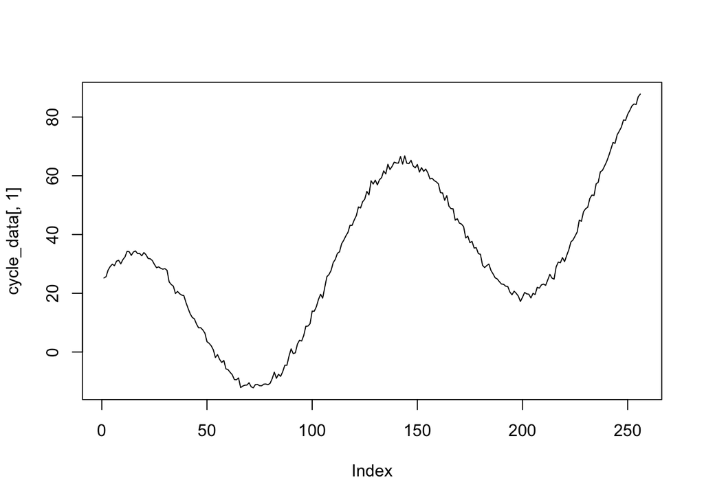

```r
plot(cycle_data[,1], type="l")
```

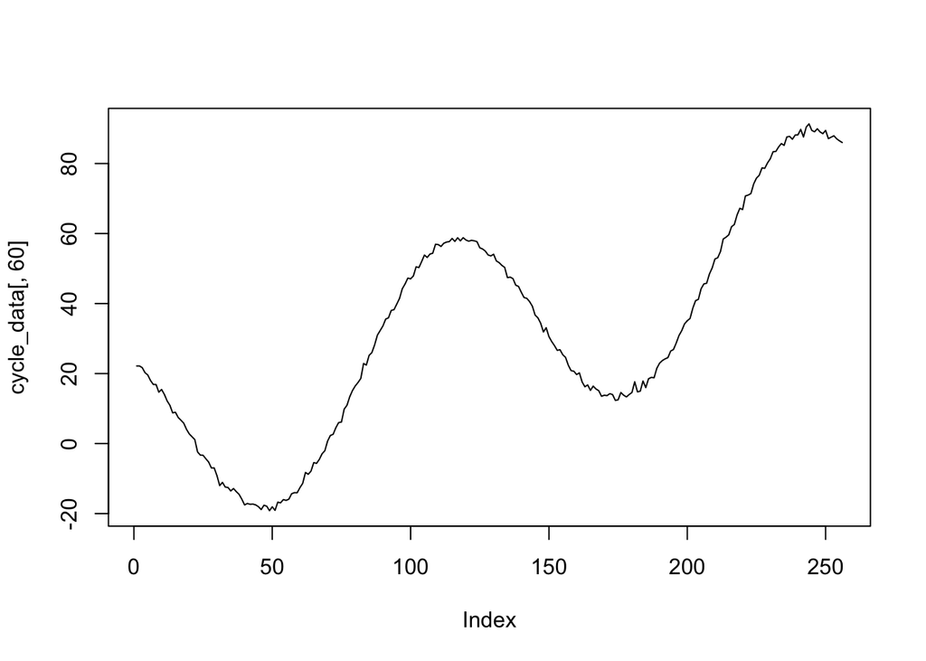

```r
plot(cycle_data[,60], type="l")
```

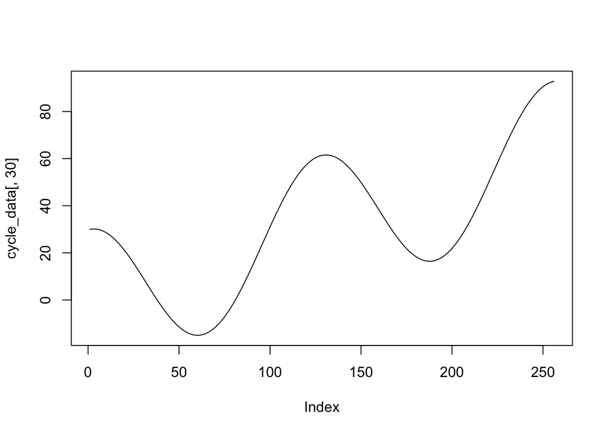

```r
plot(cycle_data[,30], type="l")
```

## A cell re-ordering of the data

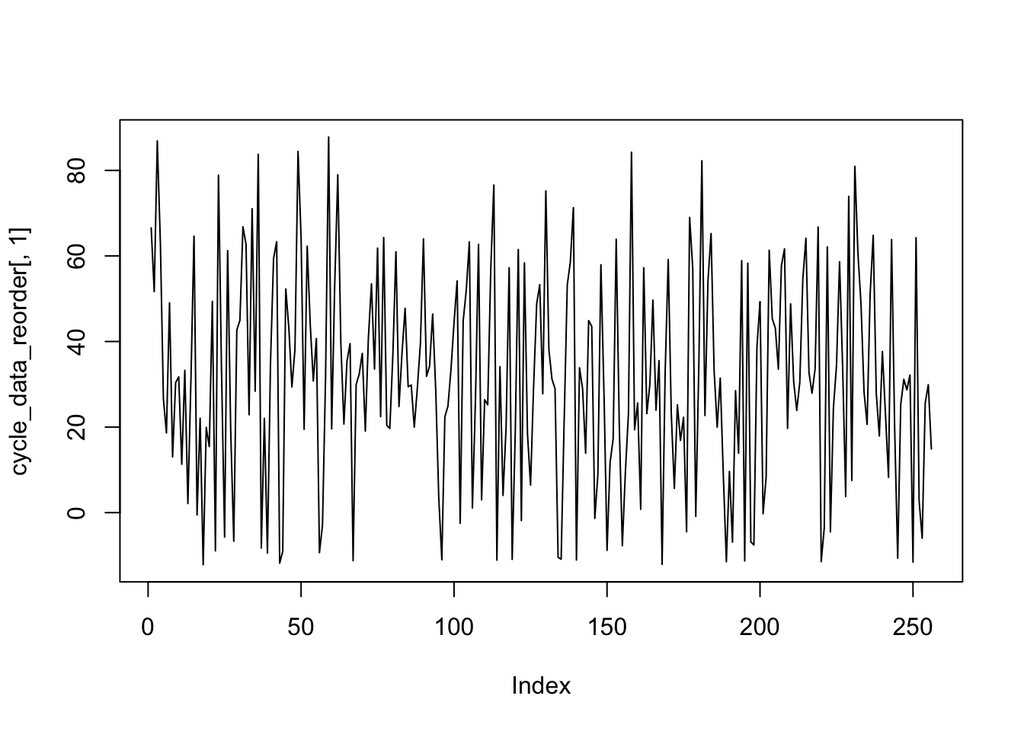

```r
sample_reorder <- sample(1:num_cells,num_cells, replace=FALSE);
cell_times_reorder <- cell_times_sim[sample_reorder];
cycle_data_reorder <- cycle_data[sample_reorder,];

plot(cycle_data_reorder[,1], type="l")
```

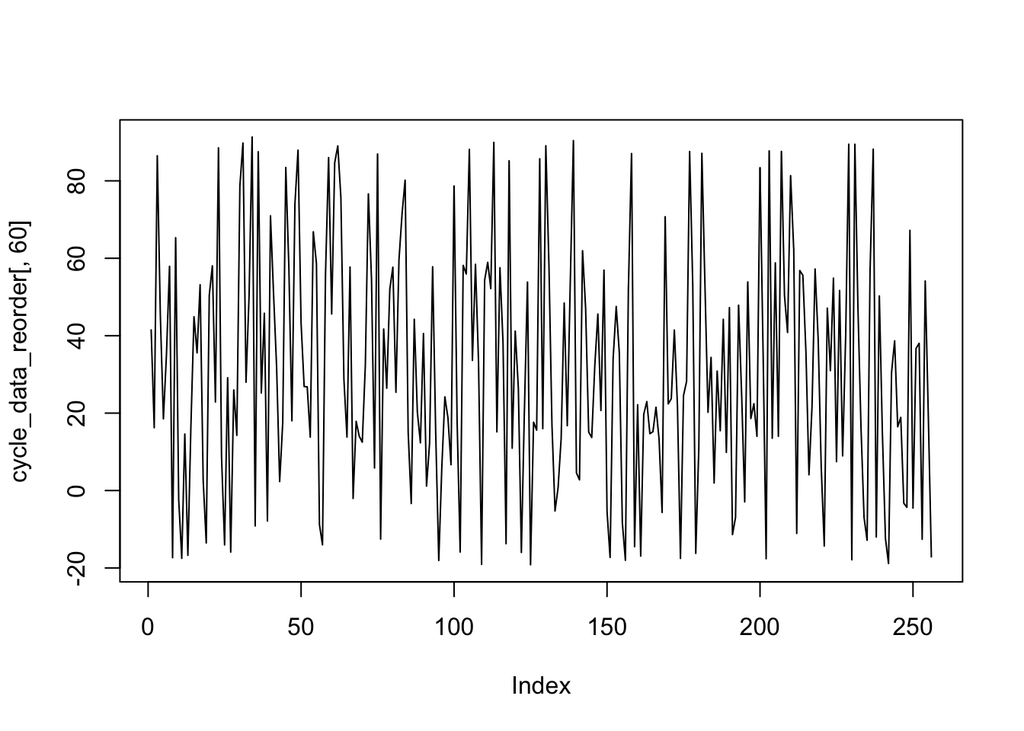

```r
plot(cycle_data_reorder[,60], type="l")
```

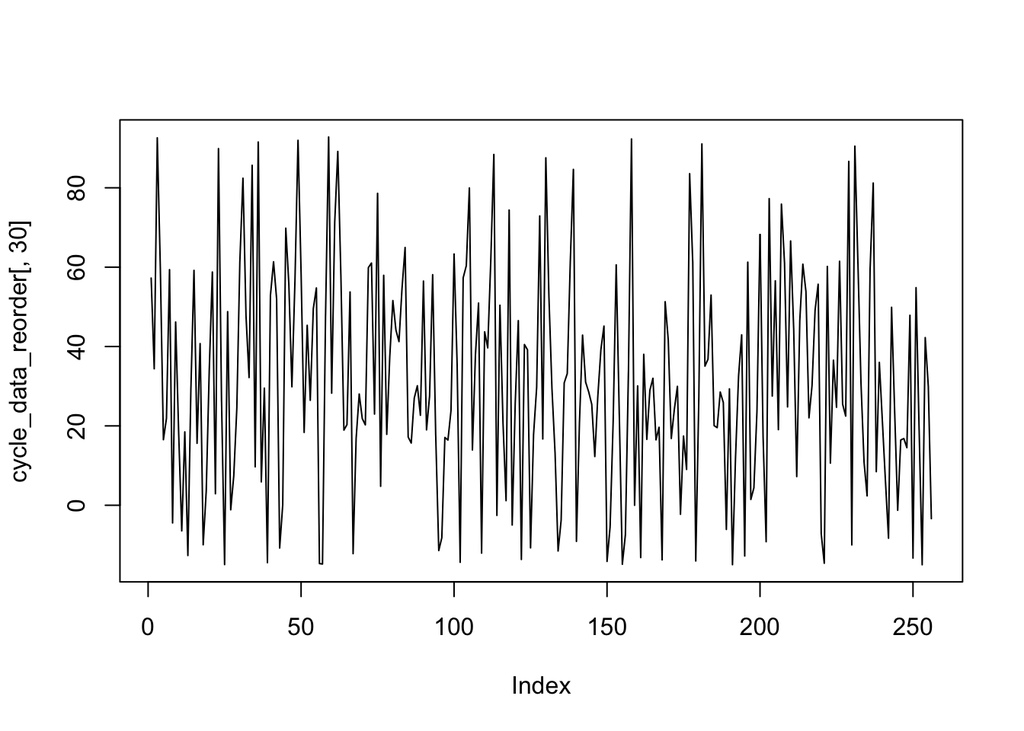

```r
plot(cycle_data_reorder[,30], type="l")
```

## Sinusoidal cellcycleR

```r
system.time(out <- sin_cell_ordering_class(cycle_data_reorder, celltime_levels = 128, num_iter=300))
```

```
## The loglikelihood after iter 1 is: -134240.604261
## The loglikelihood after iter 2 is: -114539.86828
## The loglikelihood after iter 3 is: -102364.749067
## The loglikelihood after iter 4 is: -93483.8807439
## The loglikelihood after iter 5 is: -87878.3970962
## The loglikelihood after iter 6 is: -83728.3138561
## The loglikelihood after iter 7 is: -80954.1370322
## The loglikelihood after iter 8 is: -79268.2972174
## The loglikelihood after iter 9 is: -78356.4970364
## The loglikelihood after iter 10 is: -77764.4517356
## The loglikelihood after iter 11 is: -77525.5259155
## The loglikelihood after iter 12 is: -77428.5758685
## The loglikelihood after iter 13 is: -77392.5282983
## The loglikelihood after iter 14 is: -77361.8623946
## The loglikelihood after iter 15 is: -77325.6062959
## The loglikelihood after iter 16 is: -77273.5290848
## The loglikelihood after iter 17 is: -77221.2330374
## The loglikelihood after iter 18 is: -77166.9475276
## The loglikelihood after iter 19 is: -77072.5804409
## The loglikelihood after iter 20 is: -76974.1345537
## The loglikelihood after iter 21 is: -76905.0590617
## The loglikelihood after iter 22 is: -76881.3177773
## The loglikelihood after iter 23 is: -76829.0452995
## The loglikelihood after iter 24 is: -76803.8330775
## The loglikelihood after iter 25 is: -76790.1026944
## The loglikelihood after iter 26 is: -76787.5505113
## The loglikelihood after iter 27 is: -76786.9025805
## The loglikelihood after iter 28 is: -76787.610121
## The loglikelihood after iter 29 is: -76784.0535421
## The loglikelihood after iter 30 is: -76780.00267
## The loglikelihood after iter 31 is: -76784.6190397
## The loglikelihood after iter 32 is: -76784.2533193
## The loglikelihood after iter 33 is: -76793.3132713
## The loglikelihood after iter 34 is: -76785.3286569
## The loglikelihood after iter 35 is: -76781.3566561
## The loglikelihood after iter 36 is: -76785.3294029
## The loglikelihood after iter 37 is: -76779.7022702
## The loglikelihood after iter 38 is: -76776.8139239
## The loglikelihood after iter 39 is: -76785.6170892
## The loglikelihood after iter 40 is: -76783.5591636
```

[output cut: 245 more lines]

```
## The loglikelihood after iter 286 is: -76648.9658058
## The loglikelihood after iter 287 is: -76646.5366017
## The loglikelihood after iter 288 is: -76653.7340684
## The loglikelihood after iter 289 is: -76647.7514668
## The loglikelihood after iter 290 is: -76648.928862
## The loglikelihood after iter 291 is: -76654.5006772
## The loglikelihood after iter 292 is: -76645.2066381
## The loglikelihood after iter 293 is: -76646.1140249
## The loglikelihood after iter 294 is: -76652.5129221
## The loglikelihood after iter 295 is: -76648.5352615
## The loglikelihood after iter 296 is: -76652.3872943
## The loglikelihood after iter 297 is: -76647.3194138
## The loglikelihood after iter 298 is: -76648.9419607
## The loglikelihood after iter 299 is: -76654.5591835
## The loglikelihood after iter 300 is: -76646.8646856
```

```
##    user  system elapsed
## 288.338  94.702 128.614
```

We check how the patterns look like for the genes considered above under the re-ordered cell times.

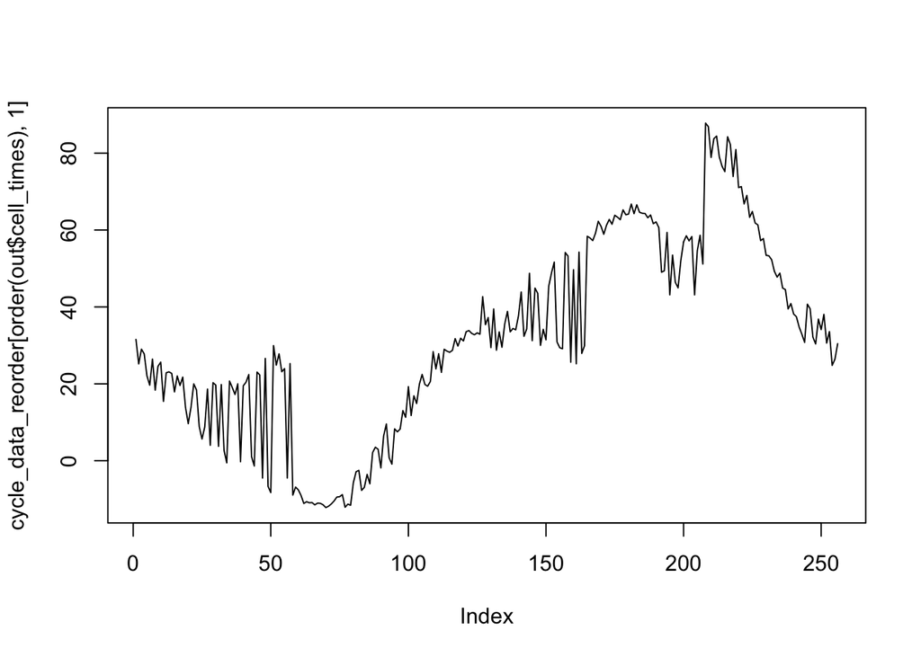

```r
plot(cycle_data_reorder[order(out$cell_times),1], type="l");
```

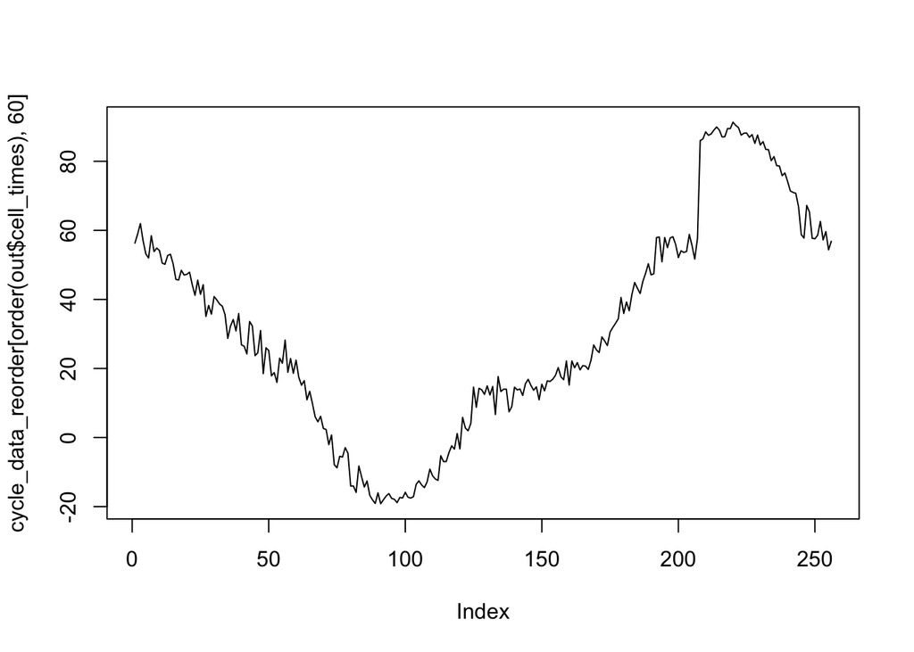

```r
plot(cycle_data_reorder[order(out$cell_times),60], type="l");
```

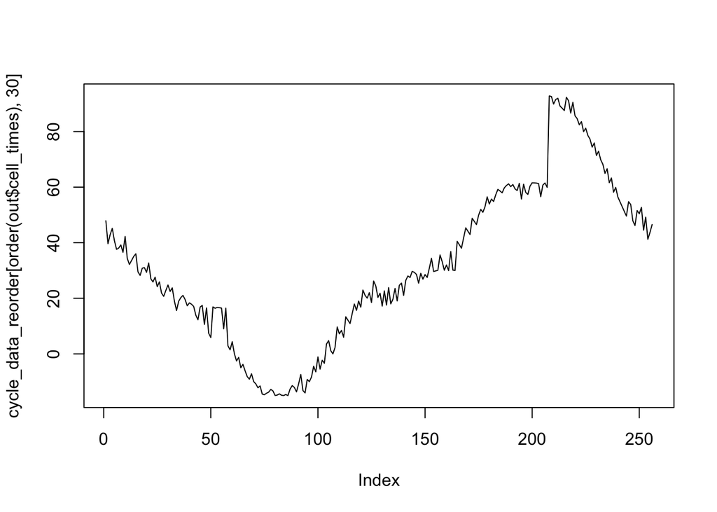

```r
plot(cycle_data_reorder[order(out$cell_times),30], type="l");
```

## Nonparameteric smoother fit on re-ordered data from sinusoidal cellcycleR

```r
system.time(smash_disp_est <- mean(sapply(1:G, function(g)
                               {
                                  mu.est.true <- smooth.spline(sort(out$cell_times), cycle_data_reorder[order(out$cell_times),g]);
                                  tab_cell_times <- as.numeric(table(out$cell_times));
                                  mu.est.y <- rep(mu.est.true$y, tab_cell_times);
                                  disp <- mean((cycle_data_reorder[order(out$cell_times),g] - mu.est.y)^2)
                                  return(disp)
                               })))
```

```
##    user  system elapsed
##   0.147   0.001   0.150
```

```r
print(smash_disp_est)
```

```
## [1] 18.3853996258
```

## Nonparameteric smoother fit on true data ordering

Now we perform the same analysis on the true data with the true order.

```r
system.time(smash_disp_true <- mean(sapply(1:G, function(g)
                               {
                                  mu.est.true <- smooth.spline(cell_times_sim, cycle_data[,g])
                                  out <- mean((cycle_data[,g] - mu.est.true$y)^2)
                                  return(out)
                               })))
```

```
##    user  system elapsed
##   0.089   0.001   0.090
```

```r
print(smash_disp_true)
```

```
## [1] 2.52232715507
```

## Discussion

Note that the average squared distance between data and the fitted curve is way higher for the re-ordered data obtain from sinusoidal or parameteric cellcycleR, thereby ensuring the fact that nonparameteric fit may indeed be useful for performing the re-ordering and may do better than parameteric or sinusoidal cellcycleR.